# R Notebook

Weekend Homework - Model Building 1 MVP We’ve looked at a few different ways in which we can build models this week, including how to prepare them properly. This weekend we’ll build a multiple linear regression model on a dataset which will need some preparation. The data can be found in the data folder, along with a data dictionary

We want to investigate the avocado dataset, and, in particular, to model the AveragePrice of the avocados. Use the tools we’ve worked with this week in order to prepare your dataset and find appropriate predictors. Once you’ve built your model use the validation techniques discussed on Wednesday to evaluate it. Feel free to focus either on building an explanatory or a predictive model, or both if you are feeling energetic!

As part of the MVP we want you not to just run the code but also have a go at intepreting the results and write your thinking in comments in your script.

Hints and tips

region may lead to many dummy variables. Think carefully about whether to include this variable or not (there is no one ‘right’ answer to this!) Think about whether each variable is categorical or numerical. If categorical, make sure that the variable is represented as a factor. We will not treat this data as a time series, so Date will not be needed in your models, but can you extract any useful features out of Date before you discard it? If you want to build a predictive model, consider using either leaps or glmulti to help with this.

```r
library(GGally)
```

I’m going to write a model that predicts the price of avocados based on apporpriate predictors.

[output not shown]

[output cut: 990 more lines]

Checking for missing data

```r
summary(avocado)
```

```
       X1             Date             AveragePrice    Total Volume           4046
 Min.   : 0.00   Min.   :2015-01-04   Min.   :0.440   Min.   :      85   Min.   :       0
 1st Qu.:10.00   1st Qu.:2015-10-25   1st Qu.:1.100   1st Qu.:   10839   1st Qu.:     854
 Median :24.00   Median :2016-08-14   Median :1.370   Median :  107377   Median :    8645
 Mean   :24.23   Mean   :2016-08-13   Mean   :1.406   Mean   :  850644   Mean   :  293008
 3rd Qu.:38.00   3rd Qu.:2017-06-04   3rd Qu.:1.660   3rd Qu.:  432962   3rd Qu.:  111020
 Max.   :52.00   Max.   :2018-03-25   Max.   :3.250   Max.   :62505647   Max.   :22743616
      4225               4770           Total Bags         Small Bags         Large Bags
 Min.   :       0   Min.   :      0   Min.   :       0   Min.   :       0   Min.   :      0
 1st Qu.:    3009   1st Qu.:      0   1st Qu.:    5089   1st Qu.:    2849   1st Qu.:    127
 Median :   29061   Median :    185   Median :   39744   Median :   26363   Median :   2648
 Mean   :  295155   Mean   :  22840   Mean   :  239639   Mean   :  182195   Mean   :  54338
 3rd Qu.:  150207   3rd Qu.:   6243   3rd Qu.:  110783   3rd Qu.:   83338   3rd Qu.:  22029
 Max.   :20470573   Max.   :2546439   Max.   :19373134   Max.   :13384587   Max.   :5719097
  XLarge Bags           type                year         region
 Min.   :     0.0   Length:18249       Min.   :2015   Length:18249
 1st Qu.:     0.0   Class :character   1st Qu.:2015   Class :character
 Median :     0.0   Mode  :character   Median :2016   Mode  :character
 Mean   :  3106.4                      Mean   :2016
 3rd Qu.:   132.5                      3rd Qu.:2017
 Max.   :551693.7                      Max.   :2018
```

starting to clean/wrangle data for model building. First i’m going to address organic/conventional

```r
avocado_clean <- avocado %>%
  mutate(organic = ifelse(type == "organic", 1, 0)) %>%
  select(-type)
```

```r
unique(avocado_clean$year)
```

```
[1] 2015 2016 2017 2018
```

```r
avocado_clean_year <-
  avocado_clean %>%
  mutate(year_2015 = ifelse(year == 2015, 1,0)) %>%
  mutate(year_2016 = ifelse(year == 2016, 1,0)) %>%
  mutate(year_2017 = ifelse(year == 2017, 1,0)) %>%
  mutate(year_2018 = ifelse(year == 2018, 1,0)) %>%
  select(-year)

avocado_clean_year
```

| X1 | Date | AveragePrice | Total Volume | 4046 | 4225 | 4770 | Total Bags | Small Bags | Large Bags | XLarge Bags | region | organic | year_2015 | year_2016 | year_2017 | year_2018 |
| --- | --- | --- | --- | --- | --- | --- | --- | --- | --- | --- | --- | --- | --- | --- | --- | --- |
| 0 | 2015-12-27 | 1.33 | 64236.62 | 1036.74 | 54454.85 | 48.16 | 8696.87 | 8603.62 | 93.25 | 0.00 | Albany | 0 | 1 | 0 | 0 | 0 |
| 1 | 2015-12-20 | 1.35 | 54876.98 | 674.28 | 44638.81 | 58.33 | 9505.56 | 9408.07 | 97.49 | 0.00 | Albany | 0 | 1 | 0 | 0 | 0 |
| 2 | 2015-12-13 | 0.93 | 118220.22 | 794.70 | 109149.67 | 130.50 | 8145.35 | 8042.21 | 103.14 | 0.00 | Albany | 0 | 1 | 0 | 0 | 0 |
| 3 | 2015-12-06 | 1.08 | 78992.15 | 1132.00 | 71976.41 | 72.58 | 5811.16 | 5677.40 | 133.76 | 0.00 | Albany | 0 | 1 | 0 | 0 | 0 |
| 4 | 2015-11-29 | 1.28 | 51039.60 | 941.48 | 43838.39 | 75.78 | 6183.95 | 5986.26 | 197.69 | 0.00 | Albany | 0 | 1 | 0 | 0 | 0 |
| 5 | 2015-11-22 | 1.26 | 55979.78 | 1184.27 | 48067.99 | 43.61 | 6683.91 | 6556.47 | 127.44 | 0.00 | Albany | 0 | 1 | 0 | 0 | 0 |
| 6 | 2015-11-15 | 0.99 | 83453.76 | 1368.92 | 73672.72 | 93.26 | 8318.86 | 8196.81 | 122.05 | 0.00 | Albany | 0 | 1 | 0 | 0 | 0 |
| 7 | 2015-11-08 | 0.98 | 109428.33 | 703.75 | 101815.36 | 80.00 | 6829.22 | 6266.85 | 562.37 | 0.00 | Albany | 0 | 1 | 0 | 0 | 0 |
| 8 | 2015-11-01 | 1.02 | 99811.42 | 1022.15 | 87315.57 | 85.34 | 11388.36 | 11104.53 | 283.83 | 0.00 | Albany | 0 | 1 | 0 | 0 | 0 |
| 9 | 2015-10-25 | 1.07 | 74338.76 | 842.40 | 64757.44 | 113.00 | 8625.92 | 8061.47 | 564.45 | 0.00 | Albany | 0 | 1 | 0 | 0 | 0 |

[output cut: 990 more lines]

Removing variables i’m not going to use as predictors.

```r
avocado_clean <- avocado_clean %>%
  select(-Date, -region)
```

Start plotting possible predictors

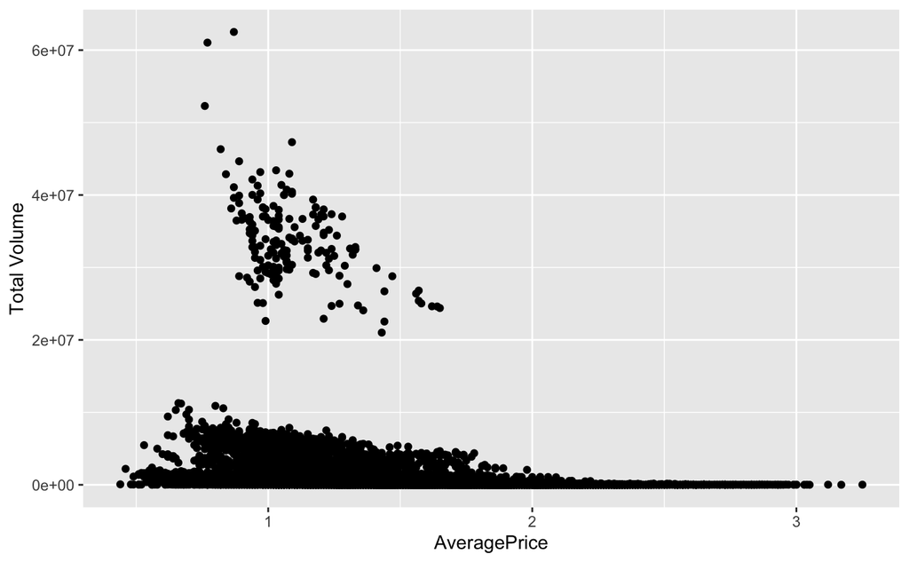

```r
avocado_clean %>%
  ggplot(aes(x = AveragePrice, y = `Total Volume`)) +
  geom_point()
```